# TreeClassification-HighRes-IndividualUser

Aitor Apaolaza

12/01/2016

*Copyright (c) 2015 The University of Manchester, UK.*

*Licenced under LGPL version 2.1. See LICENCE for details.*

*The IDInteraction Attention Classification was developed in the IDInteraction project, funded by the Engineering and Physical Sciences Research Council, UK through grant agreement number EP/M017133/1.*

*Author: Aitor Apaolaza*

## Initialisation and loading data

```
## [1] "All listed packages are already installed"
```

# Setup for the classification algorithm.

**Folder**: /home/aitor/Dropbox/UoM/IDInteractionCode/Rnotebooks

**Experiment**: dual_screen_free_experiment

**Source Videos**: high_quality

**Tracking system**: front_full_face

**Using the following list of participants**: P10.

**Using the following timelimit threshold to separate training and testing data**: 5.

Data for these participants will be read from the CSV files contained in the following folders:

/home/aitor/Dropbox/UoM/IDInteractionCode/Rnotebooks/resources/dual_screen_free_experiment/high_quality/attention/

/home/aitor/Dropbox/UoM/IDInteractionCode/Rnotebooks/resources/dual_screen_free_experiment/high_quality/front_full_face/

Loading data for participant P10

```
## [1] "Processing participant: P10"
## [1] "START of combineCSVsToDF()"
## [1] "END of combineCSVsToDF()"
## [1] "START of createFeatureDF()"
## [1] "END of createFeatureDF()"
```

## Training the tree classifier

Using the **rpart** library for the following formula:

**attentionName ~ boxHeight + boxRotation + boxArea + boxWidth + widthHeightRatio + boxYcoordRel**

Resulting model:

```
## n= 14707
##
## node), split, n, loss, yval, (yprob)
##       * denotes terminal node
##
##    1) root 14707 4165 tv (0.007887401 0.275311076 0.716801523)
##      2) boxHeight< 336.631 13280 4156 tv (0.008734940 0.304216867 0.687048193)
##        4) boxRotation< -2.94267 4612 1964 tv (0.016695577 0.409150043 0.574154380)
##          8) boxRotation>=-6.214695 2671 1297 ipad (0.001497566 0.514414077 0.484088356)
##           16) boxYcoordRel< 0.2123148 1077  282 ipad (0.003714020 0.738161560 0.258124420) *
##           17) boxYcoordRel>=0.2123148 1594  579 tv (0.000000000 0.363237139 0.636762861)
##             34) boxRotation< -5.98049 138   30 ipad (0.000000000 0.782608696 0.217391304) *
##             35) boxRotation>=-5.98049 1456  471 tv (0.000000000 0.323489011 0.676510989)
##               70) boxHeight>=200.0065 311  131 ipad (0.000000000 0.578778135 0.421221865)
##                140) boxHeight< 283.904 161    3 ipad (0.000000000 0.981366460 0.018633540) *
##                141) boxHeight>=283.904 150   22 tv (0.000000000 0.146666667 0.853333333) *
##               71) boxHeight< 200.0065 1145  291 tv (0.000000000 0.254148472 0.745851528) *
##          9) boxRotation< -6.214695 1941  586 tv (0.037609480 0.264296754 0.698093766)
##           18) boxHeight< 61.58595 270   99 ipad (0.270370370 0.633333333 0.096296296) *
##           19) boxHeight>=61.58595 1671  342 tv (0.000000000 0.204667864 0.795332136)
##             38) boxRotation< -37.38915 84    7 ipad (0.000000000 0.916666667 0.083333333) *
##             39) boxRotation>=-37.38915 1587  265 tv (0.000000000 0.166981727 0.833018273) *
##        5) boxRotation>=-2.94267 8668 2192 tv (0.004499308 0.248384864 0.747115828)
##         10) boxYcoordRel< 0.2041831 2893 1086 tv (0.013480816 0.361908054 0.624611130)
##           20) boxHeight< 277.42 1945  936 tv (0.020051414 0.461182519 0.518766067)
##             40) boxHeight< 235.7585 427  146 ipad (0.091334895 0.658079625 0.250585480)
##               80) boxHeight>=124.1645 269    0 ipad (0.000000000 1.000000000 0.000000000) *
##               81) boxHeight< 124.1645 158   51 tv (0.246835443 0.075949367 0.677215190) *
##             41) boxHeight>=235.7585 1518  616 tv (0.000000000 0.405797101 0.594202899)
##               82) boxYcoordRel>=0.199112 1354  615 tv (0.000000000 0.454209749 0.545790251)
##                164) boxRotation>=1.800175 234   28 ipad (0.000000000 0.880341880 0.119658120) *
##                165) boxRotation< 1.800175 1120  409 tv (0.000000000 0.365178571 0.634821429)
##                  330) boxHeight< 267.336 470  189 ipad (0.000000000 0.597872340 0.402127660)
##                    660) boxYcoordRel< 0.202867 223   31 ipad (0.000000000 0.860986547 0.139013453) *
##                    661) boxYcoordRel>=0.202867 247   89 tv (0.000000000 0.360323887 0.639676113)
##                     1322) boxHeight>=266.2985 85   11 ipad (0.000000000 0.870588235 0.129411765) *
##                     1323) boxHeight< 266.2985 162   15 tv (0.000000000 0.092592593 0.907407407) *
##                  331) boxHeight>=267.336 650  128 tv (0.000000000 0.196923077 0.803076923) *
##               83) boxYcoordRel< 0.199112 164    1 tv (0.000000000 0.006097561 0.993902439) *
##           21) boxHeight>=277.42 948  150 tv (0.000000000 0.158227848 0.841772152) *
##         11) boxYcoordRel>=0.2041831 5775 1106 tv (0.000000000 0.191515152 0.808484848)
##           22) boxHeight>=278.6445 1119  425 tv (0.000000000 0.379803396 0.620196604)
##             44) boxRotation< -0.4094285 438  159 ipad (0.000000000 0.636986301 0.363013699)
##               88) boxHeight< 293.539 392  115 ipad (0.000000000 0.706632653 0.293367347) *
##               89) boxHeight>=293.539 46    2 tv (0.000000000 0.043478261 0.956521739) *
##             45) boxRotation>=-0.4094285 681  146 tv (0.000000000 0.214390602 0.785609398) *
##           23) boxHeight< 278.6445 4656  681 tv (0.000000000 0.146262887 0.853737113)
##             46) boxRotation>=4.88536 909  335 tv (0.000000000 0.368536854 0.631463146)
##               92) boxHeight>=140.568 516  225 ipad (0.000000000 0.563953488 0.436046512)
##                184) boxHeight< 146.609 358   94 ipad (0.000000000 0.737430168 0.262569832) *
##                185) boxHeight>=146.609 158   27 tv (0.000000000 0.170886076 0.829113924) *
##               93) boxHeight< 140.568 393   44 tv (0.000000000 0.111959288 0.888040712) *
##             47) boxRotation< 4.88536 3747  346 tv (0.000000000 0.092340539 0.907659461) *
##      3) boxHeight>=336.631 1427    9 tv (0.000000000 0.006306938 0.993693062) *
```

From the R manual for the Complexity Parameter Table for an Rpart Fit: *The cptable in the fit contains the mean and standard deviation of the errors in the cross-validated prediction against each of the geometric means.*

Matrix of information on the optimal prunings based on a complexity parameter.

```
##
## Classification tree:
## rpart(formula = formula, data = trainsetclass, method = "class")
##
## Variables actually used in tree construction:
## [1] boxHeight    boxRotation  boxYcoordRel
##
## Root node error: 4165/14707 = 0.2832
##
## n= 14707
##
##         CP nsplit rel error  xerror     xstd
## 1 0.031032      0   1.00000 1.00000 0.013119
## 2 0.018727      5   0.84106 0.78824 0.012125
## 3 0.018607      6   0.82233 0.72029 0.011733
## 4 0.016807      8   0.78511 0.70852 0.011661
## 5 0.014118      9   0.76831 0.69028 0.011547
## 6 0.013605     20   0.57839 0.62689 0.011126
## 7 0.010084     23   0.53758 0.59808 0.010921
## 8 0.010000     24   0.52749 0.57071 0.010718
```

Visualisation of the Complexity Parameter Table. *A good choice of cp for pruning is often the leftmost value for which the mean lies below the horizontal line.*

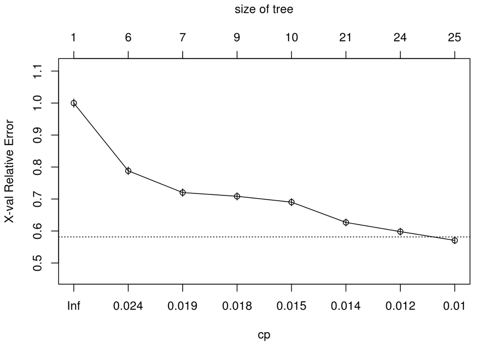

## Tree

### Summary of the tree

```
##
## Model formula:
## attentionName ~ boxHeight + boxRotation + boxArea + boxWidth +
##     widthHeightRatio + boxYcoordRel
##
## Fitted party:
## [1] root
## |   [2] boxHeight < 336.631
## |   |   [3] boxRotation < -2.94267
## |   |   |   [4] boxRotation >= -6.21469
## |   |   |   |   [5] boxYcoordRel < 0.21231: ipad (n = 1077, err = 26.2%)
## |   |   |   |   [6] boxYcoordRel >= 0.21231
## |   |   |   |   |   [7] boxRotation < -5.98049: ipad (n = 138, err = 21.7%)
## |   |   |   |   |   [8] boxRotation >= -5.98049
## |   |   |   |   |   |   [9] boxHeight >= 200.0065
## |   |   |   |   |   |   |   [10] boxHeight < 283.904: ipad (n = 161, err = 1.9%)
## |   |   |   |   |   |   |   [11] boxHeight >= 283.904: tv (n = 150, err = 14.7%)
## |   |   |   |   |   |   [12] boxHeight < 200.0065: tv (n = 1145, err = 25.4%)
## |   |   |   [13] boxRotation < -6.21469
## |   |   |   |   [14] boxHeight < 61.58595: ipad (n = 270, err = 36.7%)
## |   |   |   |   [15] boxHeight >= 61.58595
## |   |   |   |   |   [16] boxRotation < -37.38915: ipad (n = 84, err = 8.3%)
## |   |   |   |   |   [17] boxRotation >= -37.38915: tv (n = 1587, err = 16.7%)
## |   |   [18] boxRotation >= -2.94267
## |   |   |   [19] boxYcoordRel < 0.20418
## |   |   |   |   [20] boxHeight < 277.42
## |   |   |   |   |   [21] boxHeight < 235.7585
## |   |   |   |   |   |   [22] boxHeight >= 124.1645: ipad (n = 269, err = 0.0%)
## |   |   |   |   |   |   [23] boxHeight < 124.1645: tv (n = 158, err = 32.3%)
## |   |   |   |   |   [24] boxHeight >= 235.7585
## |   |   |   |   |   |   [25] boxYcoordRel >= 0.19911
## |   |   |   |   |   |   |   [26] boxRotation >= 1.80017: ipad (n = 234, err = 12.0%)
## |   |   |   |   |   |   |   [27] boxRotation < 1.80017
## |   |   |   |   |   |   |   |   [28] boxHeight < 267.336
## |   |   |   |   |   |   |   |   |   [29] boxYcoordRel < 0.20287: ipad (n = 223, err = 13.9%)
## |   |   |   |   |   |   |   |   |   [30] boxYcoordRel >= 0.20287
## |   |   |   |   |   |   |   |   |   |   [31] boxHeight >= 266.2985: ipad (n = 85, err = 12.9%)
## |   |   |   |   |   |   |   |   |   |   [32] boxHeight < 266.2985: tv (n = 162, err = 9.3%)
## |   |   |   |   |   |   |   |   [33] boxHeight >= 267.336: tv (n = 650, err = 19.7%)
## |   |   |   |   |   |   [34] boxYcoordRel < 0.19911: tv (n = 164, err = 0.6%)
## |   |   |   |   [35] boxHeight >= 277.42: tv (n = 948, err = 15.8%)
## |   |   |   [36] boxYcoordRel >= 0.20418
## |   |   |   |   [37] boxHeight >= 278.6445
## |   |   |   |   |   [38] boxRotation < -0.40943
## |   |   |   |   |   |   [39] boxHeight < 293.539: ipad (n = 392, err = 29.3%)
## |   |   |   |   |   |   [40] boxHeight >= 293.539: tv (n = 46, err = 4.3%)
## |   |   |   |   |   [41] boxRotation >= -0.40943: tv (n = 681, err = 21.4%)
## |   |   |   |   [42] boxHeight < 278.6445
## |   |   |   |   |   [43] boxRotation >= 4.88536
## |   |   |   |   |   |   [44] boxHeight >= 140.568
## |   |   |   |   |   |   |   [45] boxHeight < 146.609: ipad (n = 358, err = 26.3%)
## |   |   |   |   |   |   |   [46] boxHeight >= 146.609: tv (n = 158, err = 17.1%)
## |   |   |   |   |   |   [47] boxHeight < 140.568: tv (n = 393, err = 11.2%)
## |   |   |   |   |   [48] boxRotation < 4.88536: tv (n = 3747, err = 9.2%)
## |   [49] boxHeight >= 336.631: tv (n = 1427, err = 0.6%)
##
## Number of inner nodes:    24
## Number of terminal nodes: 25
```

### Visualisation of the tree

[figure not shown]

Tree classifier plot

## Error metrics analysis

Confusion matrix from the application of the tree predictor to the testing set of data.

```
##            predclass
##             elsewhere  ipad    tv
##   elsewhere         0     0     0
##   ipad              0   869  5602
##   tv                0  6673 17532
```

### Error metrics based on prediction of attention to the iPad.

True negatives: 17532

True positives: 869

**Error-rate**: the proportion of the incorrectly classified examples -> (fp+fn)/(tp+tn+fp+tn)

**40.0149954**

**Accuracy**: the proportion of the correctly classified examples -> (tp+tn)/(tp+tn+fp+tn)

**59.9850046**

As the number of instances of the response variable is not balanced (there are many more instances with false than true) the accuracy is not a good indicator. Other cost sensitive measures are reported here. -> cost sensitive measures

**Precision**: positive predicted value (PPV) -> tp/(tp+fp), a measure of exactness

**13.4291454**

**Recall/Sensitivity**: true positive recognition rate -> tp/(tp+fn), a measure of completeness

**11.5221427**

**Specificity**: true negative recognition rate -> tn/(tn+fp)

**75.7845595**

**F measure**: the balance between precision and recall -> 2*tp/(2*tp+fp+fn)

**12.4027689**

# ERROR MEASURES INLINE COPY

P10 **40.0149954** **59.9850046** **13.4291454** **11.5221427** **75.7845595** **12.4027689**

### Error metrics based on prediction of attention to the TV.

True negatives: 869

True positives: 17532

**Error-rate**: the proportion of the incorrectly classified examples -> (fp+fn)/(tp+tn+fp+tn)

**40.0149954**

**Accuracy**: the proportion of the correctly classified examples -> (tp+tn)/(tp+tn+fp+tn)

**59.9850046**

**Precision**: positive predicted value (PPV) -> tp/(tp+fp), a measure of exactness

**72.4313158**

**Recall/Sensitivity**: true positive recognition rate -> tp/(tp+fn), a measure of completeness

**75.7845595**

**Specificity**: true negative recognition rate -> tn/(tn+fp)

**11.5221427**

**F measure**: the balance between precision and recall -> 2*tp/(2*tp+fp+fn)

**74.0700057**